# Programming and Business Analytics

> Introduction

Kuo, Yao-Jen from [DATAINPOINT](https://www.datainpoint.com/)

## TL; DR

> In this lecture, we will walk through the "what and why" about programming and business analytics. Moreoever, a brief introduction to the programming language we will cover in the coming courses: Python.

## What is programming and business analytics

## This is just a fancy word for modern data science in order to confuse you.

## So what is modern data science?

> Modern data science is a huge field, it invovles applications and tools like importing, tidying, transformation, visualization, modeling, and communication. Surrounding all these is programming.

[figure not shown]

Source: [R for Data Science](https://r4ds.had.co.nz/)

## The sarcastic ones

[figure not shown]

Source: https://twitter.com/cdixon/status/428914681911070720/photo/1

## The more serious ones

[figure not shown]

Source: http://drewconway.com/

## Well, even "modern data science" itsel is a fancy word for...statistical analysis and data reconfiguration.

## Meet my favorite character in TV show: Chandler Bing

[figure not shown]

Source: https://giphy.com

## What is Chandler Bing's job?

[figure not shown]

Source: https://www.warnerbros.com/tv/friends/

[figure not shown]

Source: https://www.warnerbros.com/tv/friends/

[figure not shown]

Source: https://www.warnerbros.com/tv/friends/

## Topics we're gonna cover this semester

## Python, Python, and Python

- Python programming
- Data analysis with Python
- Practical Python

## What is Python

> Python is a clear and powerful object-oriented programming language.

Source: https://www.python.org/

## We will use Python to tackle everything in the pipeline

[figure not shown]

Source: [R for Data Science](https://r4ds.had.co.nz/)

## So apparently, we will use tons of Python's mighty features

- Built-in functions
- Standard libraries
- Third-party libraries

## Getting ready for programming with Python

We are using [JupyterHub](https://jupyter.org/hub), [Binder](https://mybinder.org/) and [Google Colaboratory](https://colab.research.google.com/).

## These services are all browser-based and notebook-based, so practically no "environment" that you have to setup beforehand.

## However, you are asked to sign up for these applications

- [GitHub](https://github.com/): Our JupyterHub uses GitHub to authenticate users
- [Google](https://www.google.com/): Colab uses google accounts
- [Discord](https://discord.com/): We use Discord for quick Q&A

## Why Python, anyway?

- R?
- Matlab?
- Julia?
- SAS?
- Scala?
- ...etc.

## Let's explore 3 questions in [2019 Kaggle ML & DS Survey](https://www.kaggle.com/c/kaggle-survey-2019)

- Q14: What is the primary tool that you use at work or school to analyze data?
- Q18: What programming languages do you use on a regular basis?
- Q19: What programming language would you recommend an aspiring data scientist to learn first?

## What is [Kaggle](https://kaggle.com/)

> A subsidiary of Google, is an online community of data scientists and machine learning practitioners. Kaggle allows users to find and publish data sets, explore and build models in a web-based data-science environment, work with other data scientists and machine learning engineers, and enter competitions to solve data science challenges.

Source: https://en.wikipedia.org/wiki/Kaggle

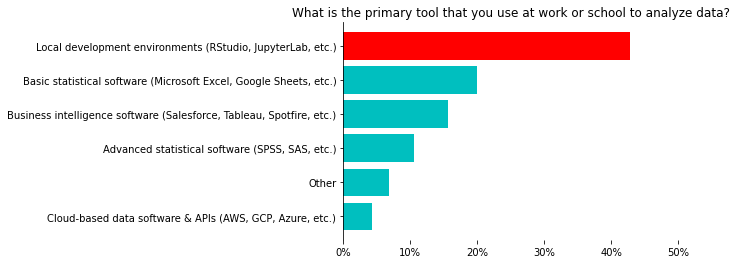

```python
# What is the primary tool that you use at work or school to analyze data?
plot_ans_14(ans_14)
```

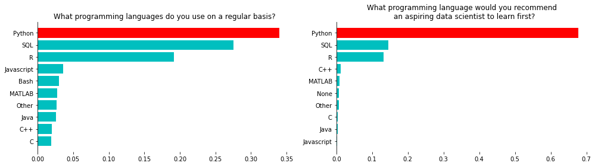

```python
# What programming languages do you use on a regular basis?
# What programming language would you recommend an aspiring data scientist to learn first?
plot_ans_18_19(ans_18, ans_19)
```

## The plots speak loud and clear.

## So what to do before our class officially begins next week?

Sign up for [GitHub](https://github.com/), [Google](https://www.google.com/), and [Discord](https://discord.com/).